# peer_assessment

Student

Friday, November 14, 2014

```r
activity <- read.csv("~/R/R_lectures/Data_cousera/reproducible/activity.csv")
activity$date <- as.Date(activity[,2], format="%m/%d/%Y")
```

# Ignoring the missing values a histogram of the total number of steps taken each day has been created

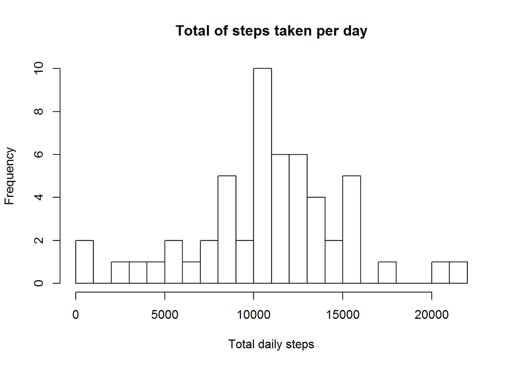

```r
hist(tapply(activity$steps, activity$date, sum), xlab = "Total daily steps", breaks = 20,
    main = "Total of steps taken per day")
```

#mean and median total number of steps taken per day is calculated

```r
total_steps <- as.numeric(tapply(activity$steps, activity$date, sum))
step_mean <- mean(total_steps, na.rm = TRUE)
step_median <- median(total_steps, na.rm = TRUE)
step_mean
```

```
## [1] 10766
```

```r
step_median
```

```
## [1] 10765
```

# Now, a time series plot (i.e. type = “l”) of the 5-minute interval (x-axis) and the average number of steps taken, averaged across all days (y-axis) is created here

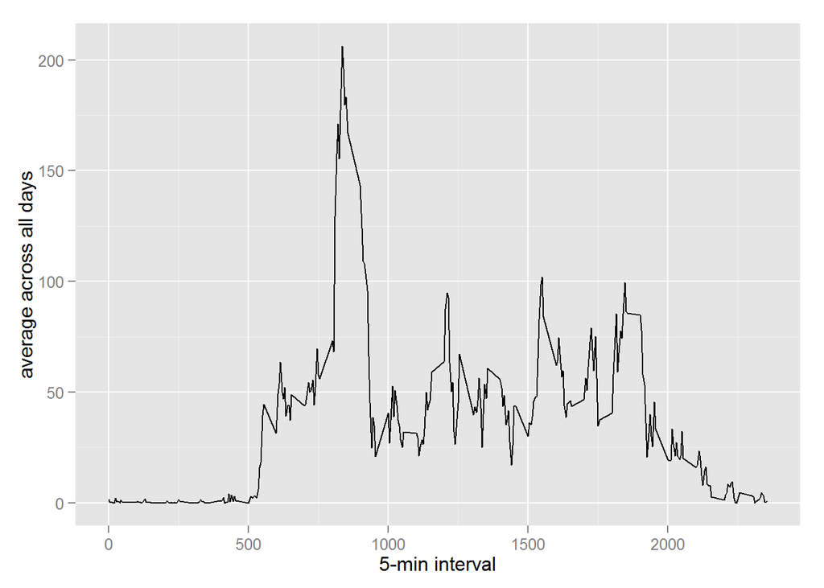

```r
library(ggplot2)
average <- aggregate(x=list(steps=activity$steps), by=list(interval=activity$interval), FUN=mean, na.rm=TRUE)
ggplot(data=average, aes(x=interval, y=steps))+geom_line()+xlab("5-min interval")+ ylab("average across all days")
```

```r
max(average$steps, na.rm=TRUE)
```

```
## [1] 206.2
```

# Number of days/intervals where there are missing values (coded as NA). The mean for the 5 min interval is used for filling in the missing values. The sum of the missing rows is calculated here.The dataset activity is split. Omitting the rows containing the dataset, a new dataset(nona_activity) is created.Another dataset with na containing rows is created(na_activity). the na containing dataset is recoded with the interval averages.Both the dataset are merged together as “imputed” dataset

```r
sum(is.na(activity$steps))
```

```
## [1] 2304
```

```r
nona_activity<-na.omit(activity)
na_activity<-activity[is.na(activity[]),]
na_activity[,1]<-sapply(na_activity[,3],function(x) round(average[average$interval==x,2]))
imputed<-rbind(nona_activity,na_activity)
imputed_activity<- tapply(imputed$steps,imputed$date,sum)
```

# Mean, median is calculated for the imputed datasets

```r
step_mean
```

```
## [1] 10766
```

```r
step_median
```

```
## [1] 10765
```

```r
mean(imputed_activity)
```

```
## [1] 10766
```

```r
median(imputed_activity)
```

```
## [1] 10762
```

```
## stat_bin: binwidth defaulted to range/30. Use 'binwidth = x' to adjust this.
```

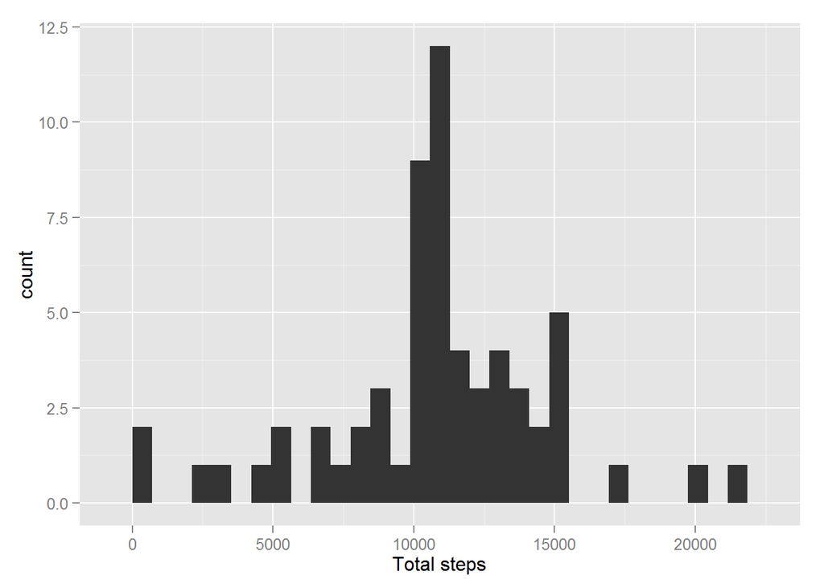

```r
qplot(imputed_activity, xlab='Total steps')
```

#After imputation the mean and median of total steps did not change much!

# Created a new factor variable in the dataset with two levels - “weekday” and “weekend” indicating whether a given date is a weekday or weekend day.

# Made a panel plot containing a time series plot (i.e. type = “l”) of the 5-minute interval (x-axis) and the average number of steps taken, averaged across all weekday days or weekend days (y-axis).

```r
library(lubridate)
imputed$day<- wday(imputed$date, label=TRUE)
imputed$daytype<- imputed$day
levels(imputed$daytype) <- list(
    weekday = c("Mon", "Tues", "Wed", "Thurs", "Fri"),
    weekend = c("Sun", "Sat"))
library(dplyr)
```

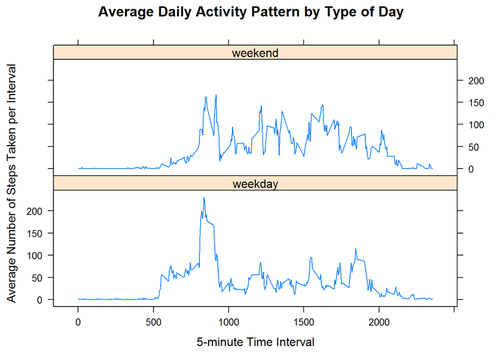

```r
activity.typeday<- imputed %>%
  group_by(daytype, interval)  %>%
  summarize(total.steps=sum(steps, na.rm=TRUE), average.steps=mean(steps, na.rm=TRUE))
library(lattice)
xyplot(average.steps~interval|daytype, data=activity.typeday, type='l', layout=(c(1,2)),
   main="Average Daily Activity Pattern by Type of Day",
   ylab="Average Number of Steps Taken per Interval", xlab="5-minute Time Interval")
```